# Apartado 4.7.2 Ejercicio 11

Daniel Ceballos Monsalve

Andrés Felipe Mejía Quintero

Doris Steffania Obando Gonzalez

29/11/2020

Librerias a utilizar

```r
library(ISLR)
library(corrplot)
library(psych)
library(MASS)
library(class)
library(Hmisc)
library(PerformanceAnalytics)
library(ggplot2)
library(vcd)
library(GGally)
library(caret)
```

## Ejercicio 11

En este problema, se un modelo para predecir si un automóvil determinado obtiene un consumo alto o bajo de combustible basado en el conjunto de datos Auto.

### Solucion enunciado del punto a

Cree una variable binaria, mpg01, que contenga un 1 si mpg contiene un valor por encima de su mediana y un 0 si mpg contiene un valor por debajo de su mediana. Puede calcular la mediana usando la función median (). Tenga en cuenta que puede resultarle útil utilizar la función data.frame () para crear un único conjunto de datos que contenga tanto mpg01 como las otras variables automáticas.

```r
summary(Auto)
```

```
##       mpg          cylinders      displacement     horsepower        weight
##  Min.   : 9.00   Min.   :3.000   Min.   : 68.0   Min.   : 46.0   Min.   :1613
##  1st Qu.:17.00   1st Qu.:4.000   1st Qu.:105.0   1st Qu.: 75.0   1st Qu.:2225
##  Median :22.75   Median :4.000   Median :151.0   Median : 93.5   Median :2804
##  Mean   :23.45   Mean   :5.472   Mean   :194.4   Mean   :104.5   Mean   :2978
##  3rd Qu.:29.00   3rd Qu.:8.000   3rd Qu.:275.8   3rd Qu.:126.0   3rd Qu.:3615
##  Max.   :46.60   Max.   :8.000   Max.   :455.0   Max.   :230.0   Max.   :5140
##
##   acceleration        year           origin                      name
##  Min.   : 8.00   Min.   :70.00   Min.   :1.000   amc matador       :  5
##  1st Qu.:13.78   1st Qu.:73.00   1st Qu.:1.000   ford pinto        :  5
##  Median :15.50   Median :76.00   Median :1.000   toyota corolla    :  5
##  Mean   :15.54   Mean   :75.98   Mean   :1.577   amc gremlin       :  4
##  3rd Qu.:17.02   3rd Qu.:79.00   3rd Qu.:2.000   amc hornet        :  4
##  Max.   :24.80   Max.   :82.00   Max.   :3.000   chevrolet chevette:  4
##                                                  (Other)           :365
```

```r
attach(Auto)
mpg01 = rep(0, length(mpg))
mpg01[mpg > median(mpg)] = 1
Auto = data.frame(Auto, mpg01)
rbind(head(Auto,5), tail(Auto,5))
```

```
##     mpg cylinders displacement horsepower weight acceleration year origin
## 1    18         8          307        130   3504         12.0   70      1
## 2    15         8          350        165   3693         11.5   70      1
## 3    18         8          318        150   3436         11.0   70      1
## 4    16         8          304        150   3433         12.0   70      1
## 5    17         8          302        140   3449         10.5   70      1
## 393  27         4          140         86   2790         15.6   82      1
## 394  44         4           97         52   2130         24.6   82      2
## 395  32         4          135         84   2295         11.6   82      1
## 396  28         4          120         79   2625         18.6   82      1
## 397  31         4          119         82   2720         19.4   82      1
##                          name mpg01
## 1   chevrolet chevelle malibu     0
## 2           buick skylark 320     0
## 3          plymouth satellite     0
## 4               amc rebel sst     0
## 5                 ford torino     0
## 393           ford mustang gl     1
## 394                 vw pickup     1
## 395             dodge rampage     1
## 396               ford ranger     1
## 397                chevy s-10     1
```

```r
str(Auto)
```

```
## 'data.frame':    392 obs. of  10 variables:
##  $ mpg         : num  18 15 18 16 17 15 14 14 14 15 ...
##  $ cylinders   : num  8 8 8 8 8 8 8 8 8 8 ...
##  $ displacement: num  307 350 318 304 302 429 454 440 455 390 ...
##  $ horsepower  : num  130 165 150 150 140 198 220 215 225 190 ...
##  $ weight      : num  3504 3693 3436 3433 3449 ...
##  $ acceleration: num  12 11.5 11 12 10.5 10 9 8.5 10 8.5 ...
##  $ year        : num  70 70 70 70 70 70 70 70 70 70 ...
##  $ origin      : num  1 1 1 1 1 1 1 1 1 1 ...
##  $ name        : Factor w/ 304 levels "amc ambassador brougham",..: 49 36 231 14 161 141 54 223 241 2 ...
##  $ mpg01       : num  0 0 0 0 0 0 0 0 0 0 ...
```

### Solucion enunciado del punto b

Explore los datos gráficamente para investigar la asociación entre mpg01 y las otras funciones. ¿Cuál de las otras características parece más útil para predecir mpg01? Los diagramas de dispersión y los diagramas de caja pueden ser herramientas útiles para responder a esta pregunta. Describe tus hallazgos.

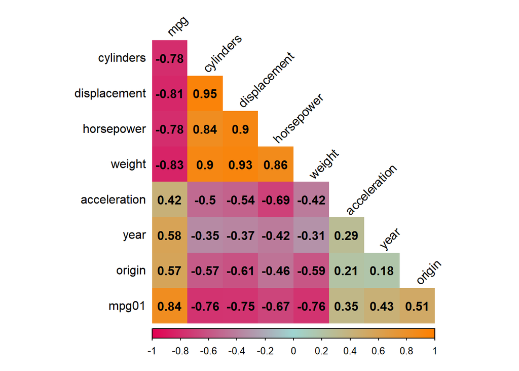

```r
Matriz_Correlacion <- round(cor(Auto[,-9]),2)

#Matriz de correlación:

col <- colorRampPalette(c("#E30052","#9FD5D1","#FF8000"))
corrplot(Matriz_Correlacion, method = "shade", type = "lower", shade.col = NA,
         tl.col = "black", tl.srt = 45, addCoef.col = "black",
         addshade = "all", col = col(300), diag = FALSE)
```

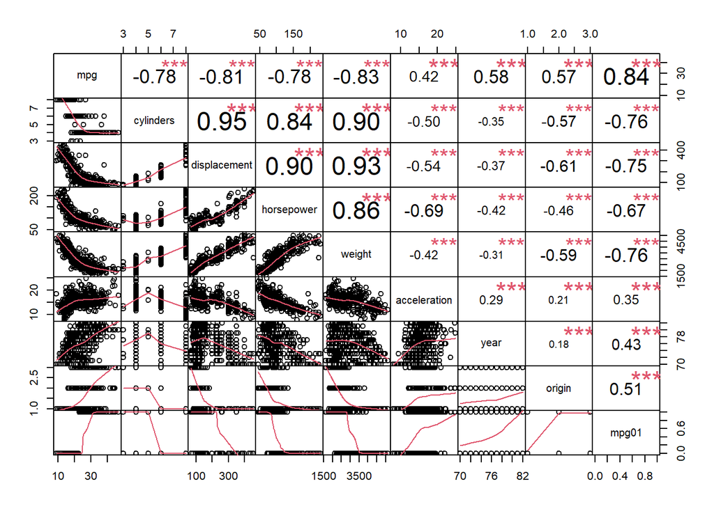

```r
#DOarama de pares:
chart.Correlation(Auto[,-9], histogram = FALSE, pch = 19)
```

### Solucion enunciado del punto c

Divida los datos en un conjunto de entrenamiento y un conjunto de prueba.

```r
set.seed(123)
indice <- createDataPartition(y = Auto$mpg01, p = 0.7, list = FALSE, times = 1)
Auto_Train = Auto[indice, ]
Auto_Test = Auto[-indice, ]
MPG01_Test = mpg01[-indice]
```

### Solucion enunciado del punto d

Realice LDA en los datos de entrenamiento para predecir mpg01 usando las variables que parecían más asociadas con mpg01 en (b). ¿Cuál es el error de prueba del modelo obtenido?

```r
# LDA
LDA1 = lda(mpg01 ~ cylinders + weight + displacement + horsepower, data = Auto_Train)
LDA_Prediccion = predict(LDA1, Auto_Test)
Proporcion_correcta = mean(LDA_Prediccion$class == MPG01_Test)
round(Proporcion_correcta,3)
```

```
## [1] 0.905
```

```r
paste("Error de prueba modelo LDA =", round((1 - Proporcion_correcta)*100,1), "%")
```

```
## [1] "Error de prueba modelo LDA = 9.5 %"
```

### Solucion enunciado del punto e

Realice QDA en los datos de entrenamiento para predecir mpg01 usando las variables que parecían más asociadas con mpg01 en (segundo). ¿Cuál es el error de prueba del modelo obtenido?

```r
# QDA
QDA_1 = qda(mpg01 ~ cylinders + weight + displacement + horsepower, data = Auto_Train)
QDA_Prediccion = predict(QDA_1, Auto_Test)
Proporcion_correcta = mean(QDA_Prediccion$class == MPG01_Test)
round(Proporcion_correcta,3)
```

```
## [1] 0.905
```

```r
paste("Error de prueba modelo QDA =", round((1 - Proporcion_correcta)*100,1), "%")
```

```
## [1] "Error de prueba modelo QDA = 9.5 %"
```

### Solucion enunciado del punto f

Realice una regresión logística en los datos de entrenamiento para predecir mpg01 usando las variables que parecían más asociadas con mpg01 en (b). ¿Cuál es el error de prueba del modelo obtenido?

```r
#REGRESION LOGISTICA
Regresion_Logistica_1 = glm(mpg01 ~ cylinders + weight + displacement + horsepower, data = Auto_Train,
    family = binomial)
Regresion_Logistica_Predicion = predict(Regresion_Logistica_1, Auto_Test, type = "response")
Regresion_Logistica_Test = rep(0, length(Regresion_Logistica_Predicion))
Regresion_Logistica_Test[Regresion_Logistica_Predicion > 0.5] = 1
Proporcion_correcta = mean(Regresion_Logistica_Test == MPG01_Test)
round(Proporcion_correcta,3)
```

```
## [1] 0.888
```

```r
paste("Error de prueba regresion logistica =", round((1 - Proporcion_correcta)*100,1), "%")
```

```
## [1] "Error de prueba regresion logistica = 11.2 %"
```

### Solucion enunciado del punto g

Realice KNN sobre los datos de entrenamiento, con varios valores de K, para predecir mpg01. Utilice solo las variables que parezcan más asociadas con mpg01 en (b). ¿Qué errores de prueba obtienes? ¿Qué valor de K parece funcionar mejor en este conjunto de datos?

```r
Train_X = cbind(cylinders, weight, displacement, horsepower)[indice, ]
Test_X = cbind(cylinders, weight, displacement, horsepower)[-indice, ]
Train_mpg01 = mpg01[indice]
set.seed(1)

# Usando KNN(k=1)
KNN1 = knn(Train_X, Test_X, Train_mpg01, k = 1)
Proporcion_correcta = mean(KNN1 == MPG01_Test)
round(Proporcion_correcta,3)
```

```
## [1] 0.879
```

```r
paste("Error de prueba con KNN (K=1) =", round((1 - Proporcion_correcta)*100,1), "%")
```

```
## [1] "Error de prueba con KNN (K=1) = 12.1 %"
```

```r
# Usando KNN(k=10)
KNN1 = knn(Train_X, Test_X, Train_mpg01, k = 10)
Proporcion_correcta = mean(KNN1 == MPG01_Test)
round(Proporcion_correcta,3)
```

```
## [1] 0.897
```

```r
paste("Error de prueba con KNN (K=10) =", round((1 - Proporcion_correcta)*100,1), "%")
```

```
## [1] "Error de prueba con KNN (K=10) = 10.3 %"
```

```r
# Usando KNN(k=50)
KNN1 = knn(Train_X, Test_X, Train_mpg01, k = 50)
Proporcion_correcta = mean(KNN1 == MPG01_Test)
round(Proporcion_correcta,3)
```

```
## [1] 0.888
```

```r
paste("Error de prueba con KNN (K=50) =", round((1 - Proporcion_correcta)*100,1), "%")
```

```
## [1] "Error de prueba con KNN (K=50) = 11.2 %"
```

```r
# Usando KNN(k=100)
KNN1 = knn(Train_X, Test_X, Train_mpg01, k = 100)
Proporcion_correcta = mean(KNN1 == MPG01_Test)
round(Proporcion_correcta,3)
```

```
## [1] 0.879
```

```r
paste("Error de prueba con KNN (K=100) =", round((1 - Proporcion_correcta)*100,1), "%")
```

```
## [1] "Error de prueba con KNN (K=100) = 12.1 %"
```